# Comparison between ESP sample and NYS population / PIAAC sample

Tianran Zhang

Haojia Li

Zihan Yang

5/26/2020

```r
# read data
library(haven)
library(readxl)
# data manipulation
library(tidyverse)
# knit tables
library(knitr)
library(table1)

# Draw ROC plot
library(ROCR)
library(pROC)
```

```r
cat.smry <- function(mat, labels = NULL) {
  perc <- paste0(round(prop.table(mat)*100,2),"%")
  n.perc <- paste0(mat,"(",perc,")")
  if(is.null(labels))
    names(n.perc) <- names(mat)
  else
    names(n.perc) <- labels
  return(n.perc)
}
```

```r
# Read the data
# raw_ES <- read_xlsx("./data/ESP19 JA - Alldata.xlsx")
raw_ESP <- read_xlsx("../Data/ESP19 JA - Alldata.xlsx")
ESP <- raw_ESP %>%
  select(gender, age, educ, hhinc, hisp, nysregion, employ, JAq1, JAq2, JAq3, JAq4)
# PIAAC <- read_spss("./data/prgusap1_puf.sav")
PIAAC <- read_spss("../Data/prgusap1_puf.sav")
```

# Data Source

## 1. Empire State Poll (ESP 2019)

The 2019Empire State Poll (ESP 2019) is the seventeenth annual general survey of New York Stateresidents age 18 and over. It is an omnibus study combining an annual core of community,economic,andsocial sciencemodules and questions submitted by academic researchers.The ESP 2019was conducted by the Survey Research Institute at Cornell University(SRI).

## 2. Program for the International Assessment of Adult Competencies (PIAAC 2017)

The PIAAC U.S. 2017 public-use file contains individual unit data including both responses to the background questionnaire and the cognitive assessment from the third U.S. PIAAC data collection, completed in 2017. Statistical disclosure control treatments were applied due to confidentiality concerns. [link](https://nces.ed.gov/pubsearch/pubsinfo.asp?pubid=2020222)

## 3. New York State Census 2016

[link](https://data.census.gov/cedsci/profile?g=0400000US36&q=New%20York)

# Demographic Comparison

## 1. ESP 2019 versus NYS 2016

### Data Description

```r
# table(ESP$gender, useNA = "ifany")
ESP <- ESP %>%
  mutate(gender = fct_recode(factor(gender), "Male"="1", "Female"="2", "Other"="3", "Refused"="-1")) %>%
  mutate(gender = factor(gender, levels = c("Male","Female","Other","Refused")))
```

```r
ESP <- ESP %>%
  mutate(age.cat = case_when(
    age == -1 ~ "Unknown",
    age < 21 ~ "18-20",
    age < 45 ~ "21-44",
    age < 65 ~ "45-64",
    age >= 65 ~ "65+"
  )) %>%
  mutate(age.cat = factor(age.cat))
```

```r
# table(ESP$educ, useNA = "ifany")
ESP <- ESP %>%
  mutate(education = case_when(
    educ == -1 ~ "Unknown",
    educ < 4 ~ "High school or less",
    educ < 6 ~ "Some college or associate's degree",
    educ < 8 ~ "Bachelor's degree or higher"
  )) %>%
  mutate(education = factor(education, levels = c("High school or less", "Some college or associate's degree", "Bachelor's degree or higher", "Unknown")))
```

```r
ESP <- ESP %>%
  mutate(income = case_when(
    is.na(hhinc) ~ -1,
   hhinc == 1 ~ 1,
   hhinc < 6 ~ 2,
    hhinc < 8 ~ 3,
   hhinc == 8 ~ 4,
    hhinc == 9 ~ 5
  )) %>%
  mutate(income = factor(income, levels = c(1:5,-1), labels = c("<$10k", "$10k-$50k", "$50k-$100k", "$100k-$150k", "$150k+", "No Data")))
```

```r
race <- raw_ESP[which(regexpr("race", colnames(raw_ESP))==1)]
colnames(race) <- c("white", "black", "natam", "asian", "other")
race[is.na(race)] = 0
race <- race %>%
  mutate(count = white+black+natam+asian+other,
         race = case_when(
           count >= 2 ~ "Unknown",
           count <= 0 | other == 1 ~ "Other",
           white == 1 ~ "White",
           black == 1 ~ "Black",
           natam == 1 ~ "Natam",
           asian == 1 ~ "Asian"),
         race = factor(race, levels = c("White", "Black", "Asian", "Natam", "Unknown", "Other")))
ESP <- cbind(ESP,race)
```

```r
ESP <- ESP %>%
  mutate(hisp = fct_recode(factor(hisp), "Non-hispanic"="0", "Hispanic"="1", "Refused"="-1")) %>%
  mutate(hisp = factor(hisp, levels = c("Hispanic", "Non-hispanic", "Refused")))
```

```r
ESP <- ESP %>%
  mutate(employ = ifelse(employ == 1, "Yes", "No")) %>%
  mutate(employ = factor(employ, levels = c("Yes", "No")))
```

```r
# NYS_age_gender <- read_xlsx("./data/nys_age_gender.xlsx", range = "A29:G32", col_names = F)
NYS_age_gender <- read_xlsx("../Data/nys_age_gender.xlsx", range = "A29:G32", col_names = F)

NYS.gender <- cat.smry(c(sum(NYS_age_gender[,4]), sum(NYS_age_gender[,6])), labels = c("Male", "Female"))
NYS.age <- cat.smry(unlist(NYS_age_gender[,2]), labels = levels(ESP$age.cat)[1:4])

# NYS_educ <- read_xlsx("./data/nys_educ.xlsx", range = "C6:Q8")[2,]
NYS_educ <- read_xlsx("../Data/nys_educ.xlsx", range = "C6:Q8")[2,]%>% unlist()
NYS.educ <- sapply(list(1:8, 9:11, 12:15), function(x) sum(NYS_educ[x])) %>% cat.smry(labels = levels(ESP$education)[1:3])

# here actually the first two levels of income for NYS is under 15k and 15k-50k
# NYS_income <- read_xls("./data/nys_income.xls", range = "D7:L7", col_names = F) %>% unlist()
NYS_income <- read_xls("../Data/nys_income.xls", range = "D7:L7", col_names = F) %>% unlist()
NYS.income <- sapply(list(1, 2:4, 3:6, 7, 8:9), function(x) round(sum(NYS_income[x])/100*128579)) %>% cat.smry(labels = c("<$10k", "$10k-$50k", "$50k-$100k", "$100k-$150k", "$150k+"))

# collapse asian alone and native hawaiian and other pacific islander alone together as asian https://www.census.gov/quickfacts/NY
NYS.race <- cat.smry(round(c(0.697,0.176,0.091,0.01,0.026)*19453561/1000), labels = c("White", "Black", "Asian", "Natam", "More than 1 race"))
NYS.hisp <- cat.smry(c(41217,250263-41217), labels = c("Hispanic", "Non-hispanic"))

# Data about employment status not found in the website; the calculation in Nat's result for employment status was incorrect
# NYS.employ <- cat.smry(c(16080891,1058919))
```

```r
ESP.smry <- c(cat.smry(table(ESP$gender)),
              cat.smry(table(ESP$age.cat)),
              cat.smry(table(ESP$education)),
              cat.smry(table(ESP$income)),
              cat.smry(table(race$race)),
              cat.smry(table(ESP$hisp)),
              cat.smry(table(ESP$employ)))
NYS.smry <- c(NYS.gender, NYS.age, NYS.educ, NYS.income, NYS.race, NYS.hisp)
comp <- data.frame(Demographic = names(ESP.smry), ESP = ESP.smry) %>%
  left_join(data.frame(d = names(NYS.smry), NYS = NYS.smry), by = c("Demographic" = "d"))

comp <- rbind(c("Gender", " ", ""), comp[1:4,],
              c("Age", "", ""), comp[5:9,],
              c("Education", "", ""), comp[10:13,],
              c("Income", "", ""), comp[14:19,],
              c("Race", "", ""), comp[20:25,],
              c("Ethnicity", "", ""), comp[26:28,],
              c("Employment", "", ""), comp[29:30,]) %>% as.data.frame()

kable(comp, row.names = F)
```

| Demographic | ESP | NYS |
| --- | --- | --- |
| Gender |  |  |
| Male | 403(50.38%) | 121301(48.41%) |
| Female | 393(49.12%) | 129262(51.59%) |
| Other | 2(0.25%) | NA |
| Refused | 2(0.25%) | NA |
| Age |  |  |
| 18-20 | 42(5.25%) | 11851(4.73%) |
| 21-44 | 298(37.25%) | 103469(41.29%) |
| 45-64 | 286(35.75%) | 82455(32.91%) |
| 65+ | 168(21%) | 52788(21.07%) |
| Unknown | 6(0.75%) | NA |
| Education |  |  |
| High school or less | 184(23%) | 97506(38.92%) |
| Some college or associate’s degree | 224(28%) | 69577(27.77%) |
| Bachelor’s degree or higher | 390(48.75%) | 83478(33.32%) |
| Unknown | 2(0.25%) | NA |
| Income |  |  |
| <$10k | 24(3%) | 13115(8.44%) |
| $10k-$50k | 229(28.62%) | 38188(24.59%) |
| $50k-$100k | 262(32.75%) | 64932(41.8%) |
| $100k-$150k | 112(14%) | 19158(12.33%) |
| $150k+ | 143(17.88%) | 19930(12.83%) |
| No Data | 30(3.75%) | NA |
| Race |  |  |
| White | 543(67.88%) | 13559(69.7%) |
| Black | 103(12.88%) | 3424(17.6%) |
| Asian | 44(5.5%) | 1770(9.1%) |
| Natam | 10(1.25%) | 195(1%) |
| Unknown | 38(4.75%) | NA |
| Other | 62(7.75%) | NA |
| Ethnicity |  |  |
| Hispanic | 126(15.75%) | 41217(16.47%) |
| Non-hispanic | 671(83.88%) | 209046(83.53%) |
| Refused | 3(0.38%) | NA |
| Employment |  |  |
| Yes | 473(59.13%) | NA |
| No | 327(40.88%) | NA |

## 2. ESP 2019 versus PIAAC 2017

### Data Description

1. Outcome: Health status – PIAAC Var name = I_Q08
- Self-reported health status
- Survey Question: In general, would you say your health is excellent, very good, good, fair, or poor?
- Continuous
1. Multi-level
- Excellent
- Very good
- Good
- Fair
- Poor
- Unknown
2. Binary
- Good
- Poor
- Unknown

```r
# Create the

PIAAC <- PIAAC %>%
  mutate(`health status (5 levels)` = case_when(
    is.na(I_Q08) ~ "Unknown",
    I_Q08 == 1 ~ "Excellent",
    I_Q08 == 2 ~ "Very Good",
    I_Q08 == 3 ~ "Good",
    I_Q08 == 4 ~ "Fair",
    I_Q08 == 5 ~ "Poor"
  )) %>%
  mutate(`health status (5 levels)`= factor(`health status (5 levels)`, levels = c("Excellent", "Very Good", "Good", "Fair", "Poor", "Unknown")))%>%
  mutate(`health status (binary)`= fct_recode(factor(`health status (5 levels)`),"Good" = "Excellent", "Good"="Good", "Good"="Very Good", "Poor"="Fair", "Poor" = "Poor"))
```

2. Predictor: Numeracy
- Numeracy scale score - Plausible value 1
- Continuous
- PIAAC var name = PVNUM1

```r
PIAAC <- PIAAC %>%
  mutate(numeracy = PVNUM1)
```

3. Covariates
1. Education
- PIAAC Var name = B_Q01A

  1 - No formal qualification or below ISCED1;  
  2 - ISCED 1;  
  3 - ISCED 2;  
  7 - ISCED 3 (without distinction A-B-C, 2y+);  
  9 - ISCED 4A-B;  
  11 - ISCED 5B;  
  12 - ISCED 5A, bachelor degree;  
  13 - ISCED 5A, master degree;  
  14 - ISCED 6;  
  15 - Foreign qualification;  
  NA - Unknown
  - PIAAC Var name = B_Q01A_T

    1 - Less than high school;  
    2 - High school;  
    3 - Above high school;  
    4 - Not definable;  
    NA - Unknown
  2. Income
- Categorical
- PIAAC Var name = J_Q09USX

  1 - <$10k;  
  2 - $10k-20k;  
  3 - $20k-30k;  
  4 - $30k-40k;  
  5 - $40k-50k;  
  6 - $50k-60k;  
  7 - $60k-75k;  
  8 - $75k-100k;  
  9 - $100k-150k;  
  10 - $150k+;  
  11 - No household income;  
  NA - Unknown
3. Race/ethnicity
- Categorical
- PIAAC Var name = RACETHN_5CAT

  N - Not stated or inferred;  
  1 - Hispanic;  
  2 - White;  
  3 - Black;  
  4 - Asian/pacific islander;  
  6 - Other race;  
  NA - Unknown

```r
PIAAC <- PIAAC %>%
  mutate(income = case_when(
    is.na(J_Q09USX) ~ -1,
    J_Q09USX %in% c(1,11) ~ 1,
    J_Q09USX < 6 ~ 2,
    J_Q09USX < 9 ~ 3,
    J_Q09USX == 9 ~ 4,
    J_Q09USX == 10 ~ 5
  )) %>%
  mutate(income = factor(income, levels = c(1:5,-1), labels = c("<$10k", "$10k-$50k", "$50k-$100k", "$100k-$150k", "$150k+", "No Data")))
# PIAAC.income <- cat.smry(table(PIAAC$income))
# PIAAC.income
```

```r
PIAAC <- PIAAC %>%
  mutate(education = case_when(
    is.na(B_Q01A_T) ~ "Unknown",
    B_Q01A_T == 1 ~ "Less than high school",
    B_Q01A_T == 2 ~ "High school",
    B_Q01A_T == 3 ~ "Above high school",
    B_Q01A_T == 4 ~ "Not definable"
  )) %>%
  mutate(education = factor(education, levels = c("Less than high school", "High school", "Above high school", "Not definable", "Unknown")))
# cat.smry(table(PIAAC$educ))
```

```r
PIAAC <- PIAAC %>%
  mutate(race = case_when(
    is.na(RACETHN_5CAT) ~ "Unknown",
    RACETHN_5CAT == 1 ~ "Hispanic",
    RACETHN_5CAT == 2 ~ "White",
    RACETHN_5CAT == 3 ~ "Black",
    RACETHN_5CAT == 4 ~ "Asian/pacific islander",
    RACETHN_5CAT == 6 ~ "Other"
  )) %>%
  mutate(race = factor(race, levels = c("White", "Black", "Asian/pacific islander", "Hispanic", "Other", "Unknown")))
# cat.smry(table(PIAAC$race))
```

4. Additional predictors – run an additional stepwise regression i.Literacy
- Literacy scale score - Plausible value 1
- Continuous
- PIAAC Var name = PVLIT1
2. Problem solving abilities
- Problem-solving scale score - Plausible value 1
- Continuous
- PIAAC Var name = PVPSL1  
  [link](https://nces.ed.gov/surveys/pisa/pisa2015/pisa2015highlights_8e.asp)  
  [link](https://www.oecd-ilibrary.org/docserver/9789264056275-7-en.pdf?expires=1590506882&id=id&accname=guest&checksum=E6F86372215D92A4AC2E8A34E843CADA)

```r
PIAAC <- PIAAC %>%
  mutate(`literacy scale score` = PVLIT1)
```

```r
PIAAC <- PIAAC %>%
  mutate(`problem-solving scale score` = PVPSL1)
```

```r
# Calculate numeracy score
ESP_demo <- ESP%>%
  mutate(numeracy = as.numeric(JAq1)+as.numeric(JAq2)+as.numeric(JAq3))%>%
  mutate(`health status (5 levels)` = case_when(
    is.na(JAq4) ~ "Unknown",
    JAq4 == 1 ~ "Excellent",
    JAq4 == 2 ~ "Very Good",
    JAq4 == 3 ~ "Good",
    JAq4 == 4 ~ "Fair",
    JAq4 == 5 ~ "Poor",
    JAq4 == -2 ~ "Unknown",
    JAq4 == -1 ~ "Unknown",
  )) %>%
  mutate(JAq4 = factor(JAq4, levels = c("Excellent", "Very Good", "Good", "Fair", "Poor", "Unknown"))) %>%
  mutate(`health status (5 levels)` = factor(`JAq4`, levels = c("Excellent", "Very Good", "Good", "Fair", "Poor", "Unknown")))%>%
mutate(`health status (binary)`= fct_recode(factor(`health status (5 levels)`),"Good" = "Excellent", "Good"="Good", "Good"="Very Good", "Poor"="Fair", "Poor" = "Poor"))%>%
  mutate(ind = factor(rep( "ESP", 800)))%>%
   dplyr::select(numeracy, `health status (binary)`, `health status (5 levels)`, income, race, education,ind)
```

## PIAAC Table 1

```r
library(compareGroups)
library(knitr)
#`literacy scale score`, `problem-solving scale score`
PIAAC_demo <- PIAAC %>%
  mutate(ind = factor(rep( "PIAAC", 3660)))%>%
  dplyr::select(numeracy, `health status (binary)`, `health status (5 levels)`, income, race, education,ind)
# merge two dataset: esp and piaac
demo <- rbind(PIAAC_demo, ESP_demo)

# PIAAC_table
PIAAC_table <- PIAAC %>%
  mutate(ind = factor(rep( "PIAAC", 3660)))%>%
  dplyr::select(numeracy, `health status (binary)`, `health status (5 levels)`, income, race, education,`literacy scale score`, `problem-solving scale score`)


PIACC_tb <- compareGroups(`health status (binary)` ~ numeracy + income + education + + race + `literacy scale score` + `problem-solving scale score`, data = PIAAC_table, byrow = TRUE, na.action = na.exclude, include.miss = TRUE)
restab <- createTable(PIACC_tb, show.n = F,show.p.overall = FALSE)
export2md(restab, caption = "PIACC Table 1 ( Health Status with 2 levels)")
```

PIACC Table 1 ( Health Status with 2 levels)

|  | Good | Poor | Unknown |
| --- | --- | --- | --- |
|  | N=2460 | N=409 | N=3 |
| Numeracy scale score - Plausible value 1 | 265 (51.6) | 244 (52.4) | 247 (59.4) |
| income: |  |  |  |
| <$10k | 84 (69.4%) | 37 (30.6%) | 0 (0.00%) |
| $10k-$50k | 674 (78.1%) | 189 (21.9%) | 0 (0.00%) |
| $50k-$100k | 785 (88.3%) | 104 (11.7%) | 0 (0.00%) |
| $100k-$150k | 384 (93.2%) | 27 (6.55%) | 1 (0.24%) |
| $150k+ | 302 (92.9%) | 23 (7.08%) | 0 (0.00%) |
| No Data | 231 (88.2%) | 29 (11.1%) | 2 (0.76%) |
| education: |  |  |  |
| Less than high school | 176 (78.6%) | 48 (21.4%) | 0 (0.00%) |
| High school | 837 (81.4%) | 190 (18.5%) | 1 (0.10%) |
| Above high school | 1441 (89.3%) | 170 (10.5%) | 2 (0.12%) |
| Not definable | 5 (83.3%) | 1 (16.7%) | 0 (0.00%) |
| Unknown | 1 (100%) | 0 (0.00%) | 0 (0.00%) |
| race: |  |  |  |
| White | 1684 (86.1%) | 269 (13.8%) | 2 (0.10%) |
| Black | 304 (84.2%) | 56 (15.5%) | 1 (0.28%) |
| Asian/pacific islander | 119 (93.0%) | 9 (7.03%) | 0 (0.00%) |
| Hispanic | 270 (84.4%) | 50 (15.6%) | 0 (0.00%) |
| Other | 78 (75.7%) | 25 (24.3%) | 0 (0.00%) |
| Unknown | 5 (100%) | 0 (0.00%) | 0 (0.00%) |
| Literacy scale score - Plausible value 1 | 280 (46.0) | 260 (47.3) | 248 (21.3) |
| Problem-solving scale score - Plausible value 1 | 273 (44.2) | 252 (47.2) | 234 (22.2) |

```r
PIACC_tb2 <- compareGroups(`health status (5 levels)` ~ numeracy + income + education + + race + `literacy scale score` + `problem-solving scale score`, data = PIAAC_table, byrow = TRUE, na.action = na.exclude, include.miss = TRUE, max.ylev = 7)
restab2 <- createTable(PIACC_tb2, show.n = F,show.p.overall = FALSE)
export2md(restab2, caption = "PIACC Table 1 ( Health Status with 5 levels)")
```

PIACC Table 1 ( Health Status with 5 levels)

|  | Excellent | Very Good | Good | Fair | Poor | Unknown |
| --- | --- | --- | --- | --- | --- | --- |
|  | N=552 | N=1030 | N=878 | N=341 | N=68 | N=3 |
| Numeracy scale score - Plausible value 1 | 267 (53.6) | 271 (48.6) | 255 (52.5) | 244 (52.7) | 243 (51.4) | 247 (59.4) |
| income: |  |  |  |  |  |  |
| <$10k | 16 (13.2%) | 27 (22.3%) | 41 (33.9%) | 31 (25.6%) | 6 (4.96%) | 0 (0.00%) |
| $10k-$50k | 129 (14.9%) | 240 (27.8%) | 305 (35.3%) | 149 (17.3%) | 40 (4.63%) | 0 (0.00%) |
| $50k-$100k | 162 (18.2%) | 346 (38.9%) | 277 (31.2%) | 94 (10.6%) | 10 (1.12%) | 0 (0.00%) |
| $100k-$150k | 97 (23.5%) | 175 (42.5%) | 112 (27.2%) | 25 (6.07%) | 2 (0.49%) | 1 (0.24%) |
| $150k+ | 93 (28.6%) | 144 (44.3%) | 65 (20.0%) | 19 (5.85%) | 4 (1.23%) | 0 (0.00%) |
| No Data | 55 (21.0%) | 98 (37.4%) | 78 (29.8%) | 23 (8.78%) | 6 (2.29%) | 2 (0.76%) |
| education: |  |  |  |  |  |  |
| Less than high school | 44 (19.6%) | 58 (25.9%) | 74 (33.0%) | 38 (17.0%) | 10 (4.46%) | 0 (0.00%) |
| High school | 168 (16.3%) | 334 (32.5%) | 335 (32.6%) | 154 (15.0%) | 36 (3.50%) | 1 (0.10%) |
| Above high school | 337 (20.9%) | 635 (39.4%) | 469 (29.1%) | 149 (9.24%) | 21 (1.30%) | 2 (0.12%) |
| Not definable | 3 (50.0%) | 2 (33.3%) | 0 (0.00%) | 0 (0.00%) | 1 (16.7%) | 0 (0.00%) |
| Unknown | 0 (0.00%) | 1 (100%) | 0 (0.00%) | 0 (0.00%) | 0 (0.00%) | 0 (0.00%) |
| race: |  |  |  |  |  |  |
| White | 379 (19.4%) | 727 (37.2%) | 578 (29.6%) | 217 (11.1%) | 52 (2.66%) | 2 (0.10%) |
| Black | 75 (20.8%) | 109 (30.2%) | 120 (33.2%) | 51 (14.1%) | 5 (1.39%) | 1 (0.28%) |
| Asian/pacific islander | 32 (25.0%) | 53 (41.4%) | 34 (26.6%) | 9 (7.03%) | 0 (0.00%) | 0 (0.00%) |
| Hispanic | 49 (15.3%) | 112 (35.0%) | 109 (34.1%) | 43 (13.4%) | 7 (2.19%) | 0 (0.00%) |
| Other | 17 (16.5%) | 25 (24.3%) | 36 (35.0%) | 21 (20.4%) | 4 (3.88%) | 0 (0.00%) |
| Unknown | 0 (0.00%) | 4 (80.0%) | 1 (20.0%) | 0 (0.00%) | 0 (0.00%) | 0 (0.00%) |
| Literacy scale score - Plausible value 1 | 281 (46.6) | 287 (43.7) | 271 (46.9) | 261 (47.4) | 254 (46.9) | 248 (21.3) |
| Problem-solving scale score - Plausible value 1 | 274 (43.8) | 279 (42.8) | 265 (44.8) | 255 (47.3) | 236 (44.0) | 234 (22.2) |

```r
load("../Data/PIAAC.RData")
```

# Regression Analysis

```r
PIAAC_clean <- PIAAC %>%
  filter(health_status != "Unknown") %>%
  mutate(health_status_1 = factor(health_status_1),
         health_status_2 = factor(health_status_2))
PIAAC_clean$race[PIAAC_clean$race == "Unknown"] = "Other"
PIAAC_clean$race <- factor(PIAAC_clean$race)
```

**With health status 1 as outcome**  
health_status_1:  
Poor: health score >=5;  
Not poor: health score < 5.

```r
univ <- function(var){
  form = formula(paste0("health_status_1 ~ ", var))
  logit = glm(form, data = PIAAC_clean, family = "binomial")
  OR = data.frame(exp(cbind(OR = coef(logit), confint(logit))))[-1, ]
  OR = cbind(OR, coef(summary(logit))[-1, 4])
  colnames(OR) <- c("OR", "2.5%", "97.5%", "p-val")
  return(OR)
}

varlist <- c("numeracy", "educ", "income.cat", "race", "literacy", "problem_solving")
univ_summary <- do.call(rbind.data.frame, lapply(varlist, univ))
univ_summary$sig <- ifelse(univ_summary$`p-val` < 0.05, "*", "")
kable(univ_summary)%>%
  kable_styling(full_width = F)
```

OR

2.5%

97.5%

p-val

sig

numeracy

0.9905021

0.9876002

9.934291e-01

0.0000000

educSome college or associate’s degree

0.4707827

0.2596094

7.969121e-01

0.0080044

educBachelor’s degree or higher

0.3522552

0.2118118

5.600179e-01

0.0000235

educUnknown

0.0000090

NA

6.736788e+23

0.9818064

income.cat$10k-$50k

0.5186317

0.3168705

8.788168e-01

0.0112519

income.cat$50k-$100k

0.1210894

0.0595283

2.384929e-01

0.0000000

income.cat$100k-$150k

0.0789418

0.0228551

2.096358e-01

0.0000040

income.cat$150k+

0.1227795

0.0406004

3.050788e-01

0.0000312

income.catNo Data

0.2883436

0.1320125

5.955932e-01

0.0010805

raceBlack

0.7777580

0.4198443

1.337515e+00

0.3915455

raceAsian/pacific islander

0.3527133

0.0577068

1.132471e+00

0.1478133

raceHispanic

0.9296147

0.5113845

1.578758e+00

0.7982552

raceOther

1.4483446

0.5981514

2.985311e+00

0.3592355

literacy

0.9879548

0.9844953

9.914113e-01

0.0000000

problem_solving

0.9832556

0.9779040

9.885218e-01

0.0000000

The result table shows that numeracy, education, income, literacy socre, and problem solving score are significant predictors for health status 1. Race seems not statistically associated with health status 1 at 0.05 significant level.

**With health status 2 as outcome**  
health_status_2:  
Not Good: health score >=4;  
Good: health score < 4.

```r
univ <- function(var){
  form = formula(paste0("health_status_2 ~ ", var))
  logit = glm(form, data = PIAAC_clean, family = "binomial")
  OR = data.frame(exp(cbind(OR = coef(logit), confint(logit))))[-1, ]
  OR = cbind(OR, coef(summary(logit))[-1, 4])
  colnames(OR) <- c("OR", "2.5%", "97.5%", "p-val")
  return(OR)
}

varlist <- c("numeracy", "educ", "income.cat", "race", "literacy", "problem_solving")
univ_summary <- do.call(rbind.data.frame, lapply(varlist, univ))
univ_summary$sig <- ifelse(univ_summary$`p-val` < 0.05, "*", "")
kable(univ_summary)%>%
  kable_styling(full_width = F)
```

OR

2.5%

97.5%

p-val

sig

numeracy

0.9904705

0.9889355

0.9919886

0.0000000

educSome college or associate’s degree

0.6348527

0.4988289

0.8022078

0.0001754

educBachelor’s degree or higher

0.3119744

0.2470346

0.3908702

0.0000000

educUnknown

1.5569007

0.0722424

16.2940474

0.7180427

income.cat$10k-$50k

0.5515764

0.4066474

0.7510627

0.0001414

income.cat$50k-$100k

0.2301329

0.1651483

0.3210700

0.0000000

income.cat$100k-$150k

0.1168319

0.0729761

0.1828925

0.0000000

income.cat$150k+

0.1267278

0.0772158

0.2023488

0.0000000

income.catNo Data

0.2728537

0.1808123

0.4082054

0.0000000

raceBlack

1.2295396

0.9565235

1.5688973

0.1013101

raceAsian/pacific islander

0.4987393

0.2724045

0.8432819

0.0150195

raceHispanic

1.2762278

0.9842709

1.6415677

0.0613277

raceOther

1.7928439

1.1911064

2.6432686

0.0039857

literacy

0.9889524

0.9871779

0.9907088

0.0000000

problem_solving

0.9896785

0.9873333

0.9920044

0.0000000

The result table shows that numeracy, education, income, literacy socre, problem solving score as well as race are significant predictors for health status 2.

## Step-wise multivariate logistic regression

**With health status 1 as outcome**  
* Outcome: health_status_1  
Poor: health score >=5;  
Not poor: health score < 5.  
* Predictor: numeracy score  
* Covariates: education, income and race.

```r
full1 <- glm(health_status_1 ~ numeracy + educ + income.cat + race, data = PIAAC_clean, family = "binomial")
final1 <- step(full1, direction = "both", trace = 0)
multi_summary1 <- exp(cbind(coef(final1), confint(final1))[-1, ]) %>% as.data.frame()
colnames(multi_summary1)[1] <- "OR"
multi_summary1$sig <- ifelse(summary(final1)$coefficients[-1, 4] < 0.05, "*", "")
kable(multi_summary1)
```

OR

2.5 %

97.5 %

sig

numeracy

0.9919422

0.9883676

0.9955348

income.cat$10k-$50k

0.5177671

0.3094978

0.8939900

income.cat$50k-$100k

0.1419513

0.0673314

0.2907074

income.cat$100k-$150k

0.1021062

0.0287198

0.2838251

income.cat$150k+

0.1716790

0.0544318

0.4533914

income.catNo Data

0.2930743

0.1321750

0.6159086

raceBlack

0.3253504

0.1687490

0.5862047

raceAsian/pacific islander

0.3258356

0.0527277

1.0717656

raceHispanic

0.4508436

0.2378465

0.8021974

raceOther

0.8793192

0.3559190

1.8618137

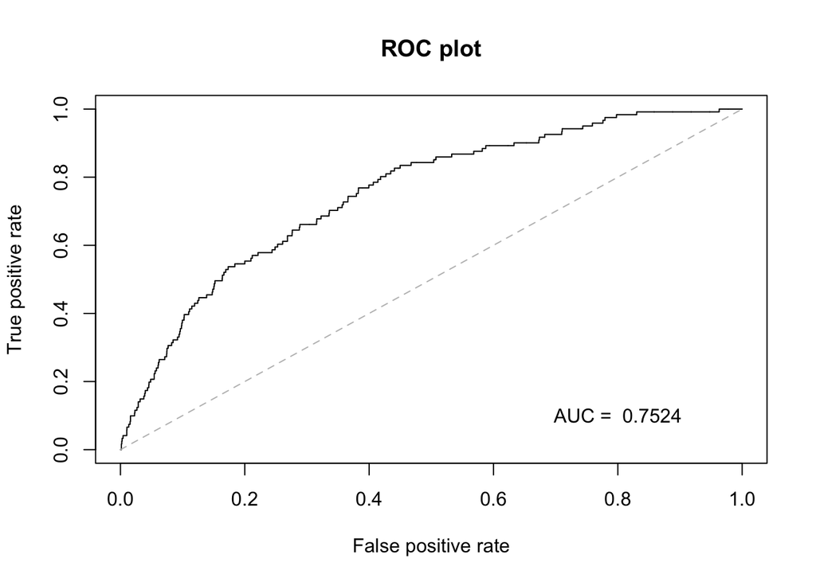

```r
# ROC curve
rocplot <- function(truth, pred, ...){
  predob = prediction(pred, truth)
  perf = performance(predob, "tpr", "fpr")
  plot(perf, colorize=F, ...)
  area = auc(truth, pred)
  area = format(round(area, 4), nsmall = 4)
  text(x = .8, y = .1, labels = paste("AUC = ", area))
  segments(x0 = 0, y0 = 0, x1 = 1, y1 = 1, col = "gray", lty = 2)
}

rocplot(PIAAC_clean$health_status_1, predict.glm(final1, PIAAC_clean, type = "response", na.action = na.omit), title = "ROC plot")
title(main = "ROC plot")
```

Significant predictors: numeracy, income, race. (No education)

```r
full2 <- glm(health_status_2 ~ numeracy + educ + income.cat + race,
             data = PIAAC_clean, family = "binomial")
final2 <- step(full2, direction = "both", trace = 0)
multi_summary2 <- exp(cbind(coef(final2), confint(final2))[-1, ]) %>%
  as.data.frame()
colnames(multi_summary2)[1] <- "OR"
multi_summary2$sig <- ifelse(summary(final2)$coefficients[-1, 4] < 0.05, "*", "")
kable(multi_summary2)
```

OR

2.5 %

97.5 %

sig

numeracy

0.9935924

0.9916773

0.9954967

educSome college or associate’s degree

0.8114810

0.6310657

1.0372196

educBachelor’s degree or higher

0.6223247

0.4775157

0.8069128

educUnknown

0.7970965

0.0353042

9.1195578

income.cat$10k-$50k

0.6128893

0.4458334

0.8456327

income.cat$50k-$100k

0.3294203

0.2306404

0.4711521

income.cat$100k-$150k

0.1961013

0.1192080

0.3163740

income.cat$150k+

0.2360451

0.1391552

0.3911916

income.catNo Data

0.3123174

0.2045410

0.4730186

raceBlack

0.6047615

0.4567735

0.7943996

raceAsian/pacific islander

0.5079503

0.2714847

0.8822769

raceHispanic

0.7193254

0.5404750

0.9493238

raceOther

1.2177017

0.7919791

1.8359722

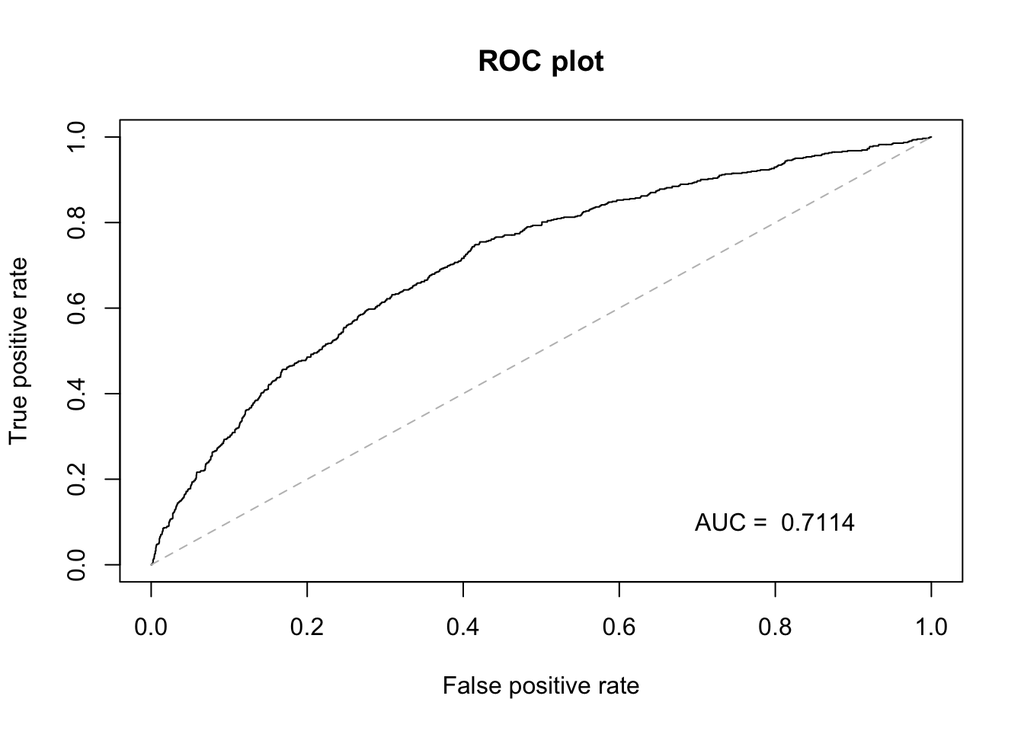

```r
rocplot(PIAAC_clean$health_status_2, predict.glm(final2, PIAAC_clean, type = "response", na.action = na.omit), title = "ROC plot")
title(main = "ROC plot")
```

Significant predictors: numeracy, education, income, race.

## Considering the additional predictors: Literacy, Problem solving abilities.

**With health status 1 as outcome**  
* Outcome: health_status_1  
Poor: health score >=5;  
Not Poor: health score < 5.  
* Predictor: numeracy score  
* Covariates: education, income, race, literacy and problem solving.

```r
PIAAC_clean2 <- na.omit(PIAAC_clean)
```

```r
full3 <- glm(health_status_1 ~ numeracy + educ + income.cat + race +
               literacy + problem_solving, data = PIAAC_clean,
             family = "binomial")
final3 <- step(full3, direction = "both", trace = 0)
multi_summary3 <- exp(cbind(coef(final3), confint(final3))[-1, ]) %>%
  as.data.frame()
colnames(multi_summary3)[1] <- "OR"
multi_summary3$sig <- ifelse(summary(final3)$coefficients[-1, 4] < 0.05, "*", "")
kable(multi_summary3)
```

OR

2.5 %

97.5 %

sig

numeracy

1.0216880

1.0123940

1.0312587

educSome college or associate’s degree

0.3545444

0.1425919

0.7604559

educBachelor’s degree or higher

0.6157253

0.3032217

1.1991616

educUnknown

0.0000012

NA

Inf

income.cat$10k-$50k

0.7956705

0.3353744

2.2092296

income.cat$50k-$100k

0.1988157

0.0681163

0.6253850

income.cat$100k-$150k

0.0921534

0.0128658

0.4324900

income.cat$150k+

0.2147306

0.0494711

0.8464002

income.catNo Data

0.3964995

0.1168485

1.3427677

raceBlack

0.3624941

0.1196066

0.8900277

raceAsian/pacific islander

0.0000004

0.0000000

366.8521315

raceHispanic

0.7584077

0.2983702

1.6770194

raceOther

1.2244016

0.3576431

3.1798357

problem_solving

0.9669017

0.9571478

0.9764345

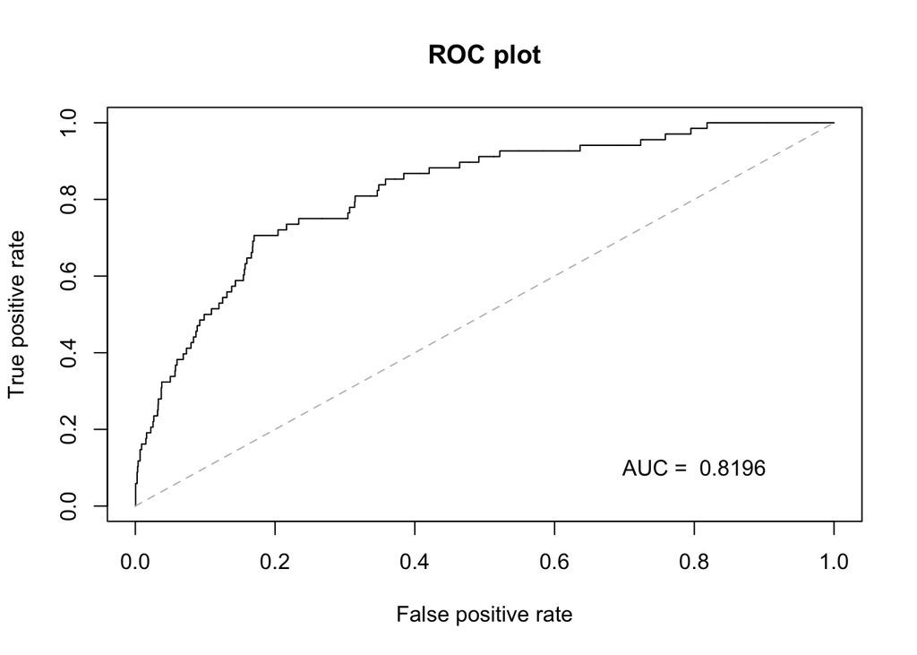

```r
rocplot(PIAAC_clean2$health_status_1, predict.glm(final3, PIAAC_clean2, type = "response", na.action = na.omit), title = "ROC plot")
title(main = "ROC plot")
```

significant predictors: numeracy, education, income, race, problem solving

```r
full4 <- glm(health_status_2 ~ numeracy + educ + income.cat + race +
               literacy + problem_solving,
             data = PIAAC_clean, family = "binomial")
final4 <- step(full4, direction = "both", trace = 0)
multi_summary4 <- exp(cbind(coef(final4), confint(final4))[-1, ]) %>%
  as.data.frame()
colnames(multi_summary4)[1] <- "OR"
multi_summary4$sig <- ifelse(summary(final4)$coefficients[-1, 4] < 0.05, "*", "")
kable(multi_summary4)
```

OR

2.5 %

97.5 %

sig

numeracy

1.0036429

0.9997151

1.007599e+00

educSome college or associate’s degree

0.8290524

0.6207729

1.098788e+00

educBachelor’s degree or higher

0.6265949

0.4648257

8.402878e-01

educUnknown

0.0000248

NA

1.341506e+24

income.cat$10k-$50k

0.6507868

0.4238658

1.013762e+00

income.cat$50k-$100k

0.3587609

0.2265064

5.747573e-01

income.cat$100k-$150k

0.2148115

0.1192861

3.825016e-01

income.cat$150k+

0.2486465

0.1330533

4.570113e-01

income.catNo Data

0.3007867

0.1707764

5.248215e-01

raceBlack

0.7257169

0.5098116

1.018421e+00

raceAsian/pacific islander

0.5516735

0.2537015

1.060898e+00

raceHispanic

0.9237138

0.6431603

1.306327e+00

raceOther

1.4482671

0.8781530

2.315563e+00

problem_solving

0.9895169

0.9854079

9.936153e-01

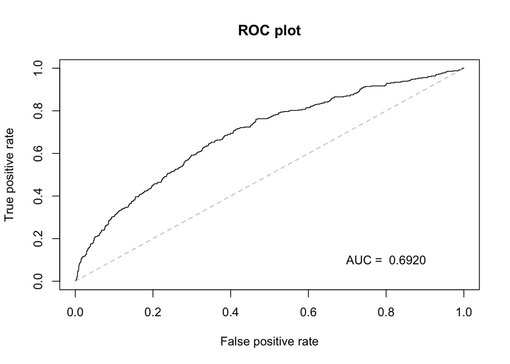

```r
rocplot(PIAAC_clean2$health_status_2, predict.glm(final4, PIAAC_clean2, type = "response", na.action = na.omit), title = "ROC plot")
title(main = "ROC plot")
```

### Summary

ESP

PIAAC

- Outcome: health status 1
- predictor & covariates: numeracy score & income, race, (education)
- AUC: 0.7524
- Outcome: health status 2
- predictor & covariates: numeracy score & income, race, **education**
- AUC: 0.7114
- Outcome: health status 1
- predictor & covariates: numeracy score & income, race, **education**, problem_solving, (literacy score)
- AUC: 0.8196
- Outcome: health status 2
- predictor & covariates: numeracy score & income, race, **education**, problem solving, (literacy score).
- AUC: 0.6920

As for additional predictors, problem solving score is significant while literacy score is not significant no matter which cut point to set.